# matplotlib library

```python
import matplotlib.pyplot as plt
```

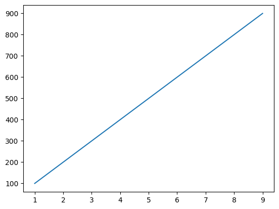

```python
x=[1,2,3,4,5,6,7,8,9]
y=[100,200,300,400,500,600,700,800,900]
plt.plot(x,y)
plt.show()
```

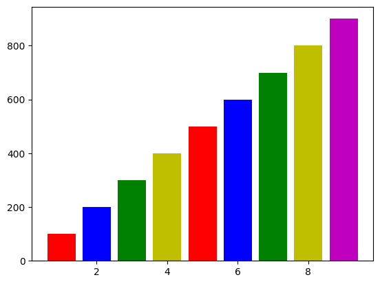

```python
x=[1,2,3,4,5,6,7,8,9]
y=[100,200,300,400,500,600,700,800,900]
c=['r','b','g','y','r','b','g','y','m']
plt.bar(x,y,color=c)
plt.show()
```

# How to use bar plot all concept

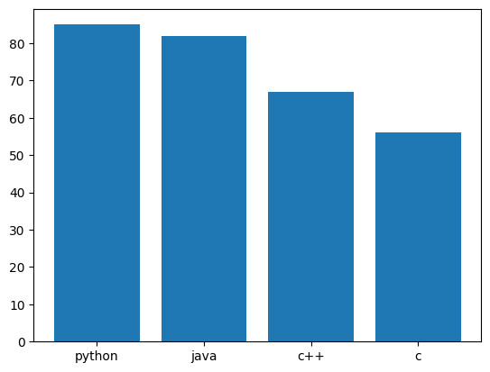

```python
x=["python","java","c++","c"]
y=[85,82,67,56]
plt.bar(x,y)
plt.show()
```

**adding label and title on bar graph**

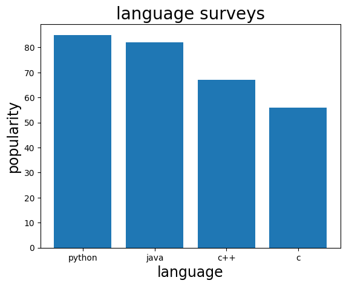

```python
x=["python","java","c++","c"]
y=[85,82,67,56]

plt.xlabel("language",fontsize=17)
plt.ylabel("popularity",fontsize=17)

plt.title("language surveys",fontsize=20)

plt.bar(x,y)
plt.show()
```

**changing color or graph width**

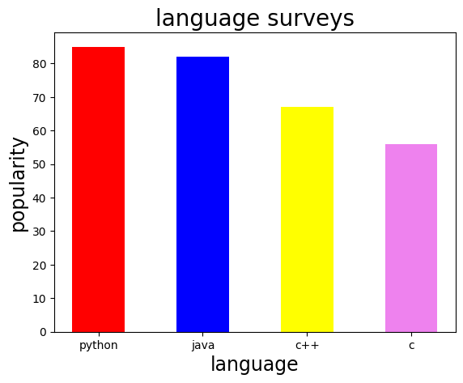

```python
x=["python","java","c++","c"]
y=[85,82,67,56]

plt.xlabel("language",fontsize=17)
plt.ylabel("popularity",fontsize=17)

plt.title("language surveys",fontsize=20)

c=['red','b','yellow',"violet"]

plt.bar(x,y,width=0.5,color=c)
plt.show()
```

**some parameters**  
**align: it moves the xlabel to "center" or "edge"**  
**edgecolor: it color the boundary of plot by color given**  
**linewidth: it decides the width line of boundary**  
**linestyle: it change the style of boundary from default**  
**alpha: it decides the color contrast of plots vary from 0-1**

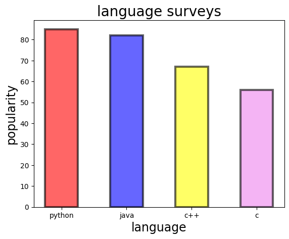

```python
x=["python","java","c++","c"]
y=[85,82,67,56]

plt.xlabel("language",fontsize=17)
plt.ylabel("popularity",fontsize=17)

plt.title("language surveys",fontsize=20)

c=['red','b','yellow',"violet"]

plt.bar(x,y,width=0.5,color=c,align="center",edgecolor="black",linewidth='3',
        linestyle='-',alpha=0.6)
plt.show()
```

**label parameter can be used to put label within plot sheet and can be used to by plt.legend() key**

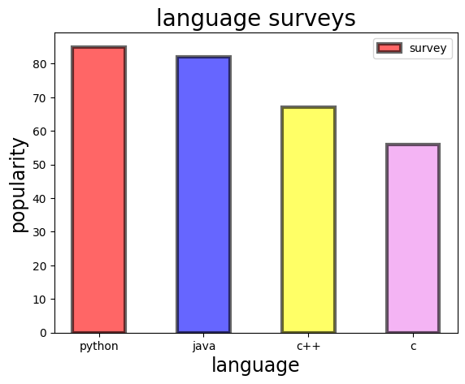

```python
x=["python","java","c++","c"]
y=[85,82,67,56]

plt.xlabel("language",fontsize=17)
plt.ylabel("popularity",fontsize=17)

plt.title("language surveys",fontsize=20)

c=['red','b','yellow',"violet"]

plt.bar(x,y,width=0.5,color=c,align="center",edgecolor="black",linewidth='3',
        linestyle='-',alpha=0.6,label="survey")
plt.legend()
plt.show()
```

# plotting two bar at single sheet

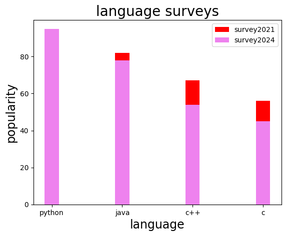

```python
import numpy as np

x=["python","java","c++","c"]
y=[85,82,67,56]
z=[95,78,54,45]

width=0.2
p=np.arange(len(x))



plt.xlabel("language",fontsize=17)
plt.ylabel("popularity",fontsize=17)
plt.title("language surveys",fontsize=20)



plt.bar(x,y,width,color="red",label="survey2021")
plt.bar(x,z,width,color="violet",label="survey2024")

plt.legend()
plt.show()
```

**in above program there is an issue that the one plot is on another if we want to plot sidewise with each category we use a for loop method as p1**

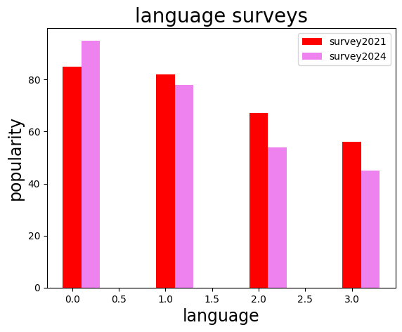

```python
x=["python","java","c++","c"]
y=[85,82,67,56]
z=[95,78,54,45]

width=0.2
p=np.arange(len(x))
p1=[i+width for i in p]




plt.xlabel("language",fontsize=17)
plt.ylabel("popularity",fontsize=17)
plt.title("language surveys",fontsize=20)



plt.bar(p,y,width,color="red",label="survey2021")
plt.bar(p1,z,width,color="violet",label="survey2024")

plt.legend()
plt.show()
```

**there is one more problem we can see that in lanaguage ther s some numbers instead of name of programmig so we use "plt.xticks()" or two align name in center we use p+width/2**

**rotation of text can also be done by rotation=**

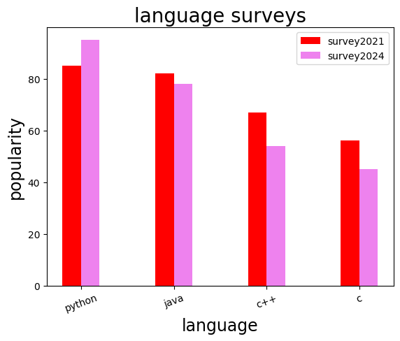

```python
x=["python","java","c++","c"]
y=[85,82,67,56]
z=[95,78,54,45]

width=0.2
p=np.arange(len(x))
p1=[i+width for i in p]




plt.xlabel("language",fontsize=17)
plt.ylabel("popularity",fontsize=17)
plt.title("language surveys",fontsize=20)



plt.bar(p,y,width,color="red",label="survey2021")
plt.bar(p1,z,width,color="violet",label="survey2024")

plt.xticks(p+width/2,x,rotation=20)
plt.legend()
plt.show()
```

**if we want to plot horizontal bar we use plt.barh() instead of plt.bar()**

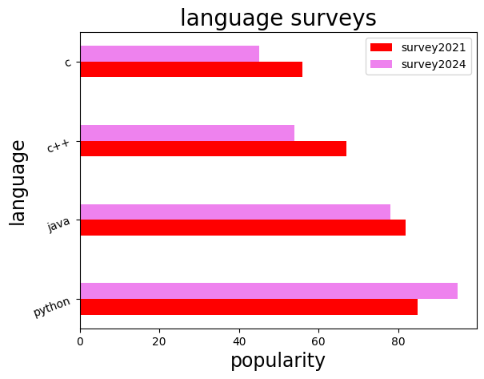

```python
y=["python","java","c++","c"]
x=[85,82,67,56]
z=[95,78,54,45]

width=0.2
p=np.arange(len(y))
p1=[i+width for i in p]




plt.ylabel("language",fontsize=17)
plt.xlabel("popularity",fontsize=17)
plt.title("language surveys",fontsize=20)



plt.barh(p,x,width,color="red",label="survey2021")
plt.barh(p1,z,width,color="violet",label="survey2024")


plt.yticks(p+width/2,y,rotation=20)
plt.legend()
plt.show()
```

# How to use scatter plot all concept

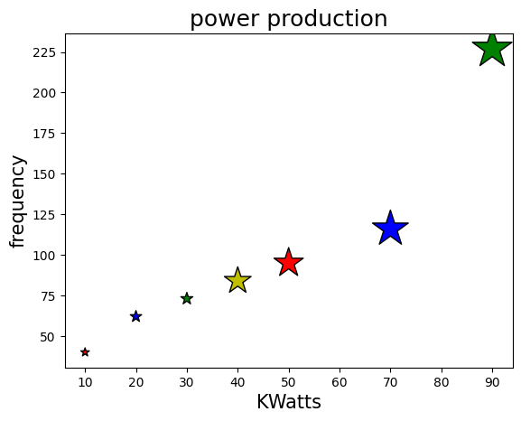

```python
import matplotlib.pyplot as plt

x=[10,20,30,40,50,70,90]
y=[40,62,73,84,95,116,227]

c=["r",'b','g','y',"r","b","g"]
sizes=[50,90,100,500,600,900,1100]

plt.scatter(x,y,color=c,s=sizes,marker="*",edgecolor="black")

plt.title("power production",fontsize=18)
plt.xlabel("KWatts",fontsize=15)
plt.ylabel("frequency",fontsize=15)

plt.show()
```

**cmap: used to show the color bondary level such as accent,binary,viridis etc.**

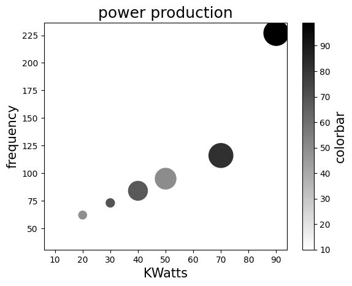

```python
x=[10,20,30,40,50,70,90]
y=[40,62,73,84,95,116,227]

sizes=[50,90,100,500,600,800,850]
colors=[10,49,70,68,50,82,99]

plt.scatter(x,y,c=colors,s=sizes,cmap="binary")
t=plt.colorbar()
t.set_label("colorbar",fontsize=15)

plt.title("power production",fontsize=18)
plt.xlabel("KWatts",fontsize=15)
plt.ylabel("frequency",fontsize=15)


plt.show()
```

**for two scatter plot in one graph**

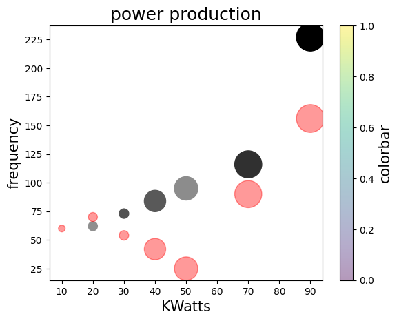

```python
x=[10,20,30,40,50,70,90]
y=[40,62,73,84,95,116,227]
z=[60,70,54,42,25,90,156]

sizes=[50,90,100,500,600,800,850]
colors=[10,49,70,68,50,82,99]

plt.scatter(x,y,c=colors,s=sizes,cmap="binary")
plt.scatter(x,z,color="r",s=sizes,alpha=0.4)

t=plt.colorbar()
t.set_label("colorbar",fontsize=15)

plt.title("power production",fontsize=18)
plt.xlabel("KWatts",fontsize=15)
plt.ylabel("frequency",fontsize=15)


plt.show()
```

# How to plot histogram chart

```python
import matplotlib.pyplot as plt
import numpy as np
import random

x=np.random.randint(10,60,(50))
print(x)
```

```
[46 50 40 12 26 37 59 34 25 32 16 50 21 16 31 24 18 39 40 29 49 19 42 16
 46 59 46 39 39 40 57 20 35 11 52 34 39 38 16 28 32 24 26 46 53 17 37 42
 21 18]
```

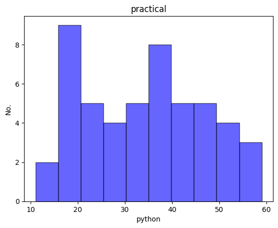

```python
np=[46, 50 ,40 ,12, 26 ,37,59 ,34 ,25, 32, 16 ,50, 21, 16, 31, 24, 18,39 ,40 ,29 ,49 ,19 ,42 ,16,
 46, 59 ,46 ,39 ,39 ,40 ,57 ,20 ,35 ,11 ,52 ,34 ,39, 38 ,16 ,28, 32 ,24 ,26 ,46 ,53 ,17, 37 ,42,
 21, 18]
plt.hist(np,color="b",edgecolor="black",alpha=0.6)

plt.title("practical")
plt.xlabel("python")
plt.ylabel("No.")

plt.show()
```

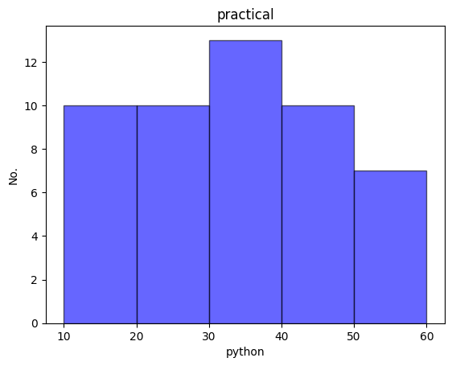

```python
np=[46, 50 ,40 ,12, 26 ,37,59 ,34 ,25, 32, 16 ,50, 21, 16, 31, 24, 18,39 ,40 ,29 ,49 ,19 ,42 ,16,
 46, 59 ,46 ,39 ,39 ,40 ,57 ,20 ,35 ,11 ,52 ,34 ,39, 38 ,16 ,28, 32 ,24 ,26 ,46 ,53 ,17, 37 ,42,
 21, 18]
l=[10,20,30,40,50,60]
plt.hist(np,color="b",bins=l,edgecolor="black",alpha=0.6)

plt.title("practical")
plt.xlabel("python")
plt.ylabel("No.")

plt.show()
```

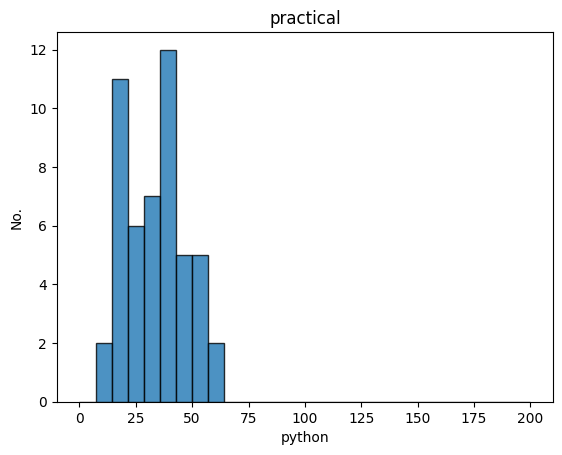

```python
np=[46, 50 ,40 ,12, 26 ,37,59 ,34 ,25, 32, 16 ,50, 21, 16, 31, 24, 18,39 ,40 ,29 ,49 ,19 ,42 ,16,
 46, 59 ,46 ,39 ,39 ,40 ,57 ,20 ,35 ,11 ,52 ,34 ,39, 38 ,16 ,28, 32 ,24 ,26 ,46 ,53 ,17, 37 ,42,
 21, 18]
l=[10,20,30,40,50,60]
plt.hist(np,"auto",(0,200),edgecolor="black",alpha=0.8)

plt.title("practical")
plt.xlabel("python")
plt.ylabel("No.")

plt.show()
```

**cumulative parameter reverses the order of plot**

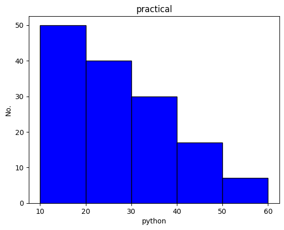

```python
np=[46, 50 ,40 ,12, 26 ,37,59 ,34 ,25, 32, 16 ,50, 21, 16, 31, 24, 18,39 ,40 ,29 ,49 ,19 ,42 ,16,
 46, 59 ,46 ,39 ,39 ,40 ,57 ,20 ,35 ,11 ,52 ,34 ,39, 38 ,16 ,28, 32 ,24 ,26 ,46 ,53 ,17, 37 ,42,
 21, 18]
l=[10,20,30,40,50,60]
plt.hist(np,color="b",bins=l,edgecolor="black",cumulative=-1)

plt.title("practical")
plt.xlabel("python")
plt.ylabel("No.")

plt.show()
```

**bottom parameter can be used to run graph from desired number rather than from 0 or beginning**

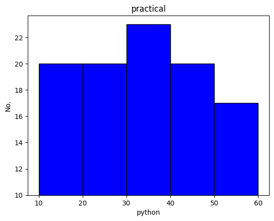

```python
np=[46, 50 ,40 ,12, 26 ,37,59 ,34 ,25, 32, 16 ,50, 21, 16, 31, 24, 18,39 ,40 ,29 ,49 ,19 ,42 ,16,
 46, 59 ,46 ,39 ,39 ,40 ,57 ,20 ,35 ,11 ,52 ,34 ,39, 38 ,16 ,28, 32 ,24 ,26 ,46 ,53 ,17, 37 ,42,
 21, 18]
l=[10,20,30,40,50,60]
plt.hist(np,color="b",bins=l,edgecolor="black",bottom=10)

plt.title("practical")
plt.xlabel("python")
plt.ylabel("No.")

plt.show()
```

**we can also change histtype or which type of graph we want**

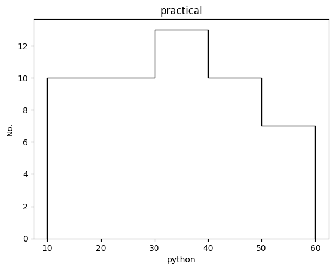

```python
np=[46, 50 ,40 ,12, 26 ,37,59 ,34 ,25, 32, 16 ,50, 21, 16, 31, 24, 18,39 ,40 ,29 ,49 ,19 ,42 ,16,
 46, 59 ,46 ,39 ,39 ,40 ,57 ,20 ,35 ,11 ,52 ,34 ,39, 38 ,16 ,28, 32 ,24 ,26 ,46 ,53 ,17, 37 ,42,
 21, 18]
l=[10,20,30,40,50,60]
plt.hist(np,color="b",bins=l,edgecolor="black",histtype="step")

plt.title("practical")
plt.xlabel("python")
plt.ylabel("No.")

plt.show()
```

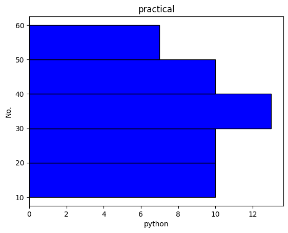

```python
np=[46, 50 ,40 ,12, 26 ,37,59 ,34 ,25, 32, 16 ,50, 21, 16, 31, 24, 18,39 ,40 ,29 ,49 ,19 ,42 ,16,
 46, 59 ,46 ,39 ,39 ,40 ,57 ,20 ,35 ,11 ,52 ,34 ,39, 38 ,16 ,28, 32 ,24 ,26 ,46 ,53 ,17, 37 ,42,
 21, 18]
l=[10,20,30,40,50,60]
plt.hist(np,color="b",bins=l,edgecolor="black",orientation="horizontal")

plt.title("practical")
plt.xlabel("python")
plt.ylabel("No.")

plt.show()
```

**rwidth added the space between the hist and plot**

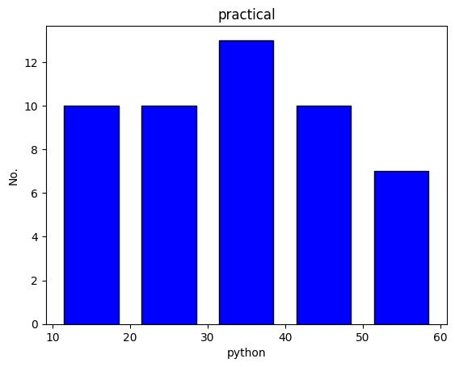

```python
np=[46, 50 ,40 ,12, 26 ,37,59 ,34 ,25, 32, 16 ,50, 21, 16, 31, 24, 18,39 ,40 ,29 ,49 ,19 ,42 ,16,
 46, 59 ,46 ,39 ,39 ,40 ,57 ,20 ,35 ,11 ,52 ,34 ,39, 38 ,16 ,28, 32 ,24 ,26 ,46 ,53 ,17, 37 ,42,
 21, 18]
l=[10,20,30,40,50,60]
plt.hist(np,color="b",bins=l,edgecolor="black",rwidth=0.7)

plt.title("practical")
plt.xlabel("python")
plt.ylabel("No.")

plt.show()
```

**by using log parameter we can convert into log histgraph**

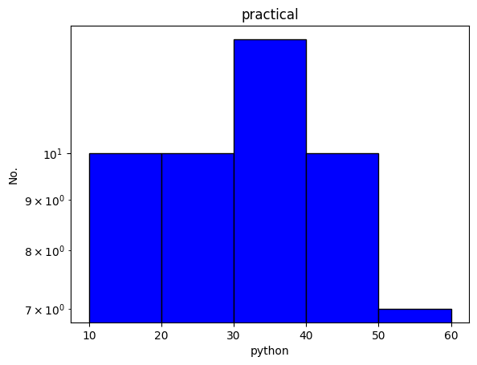

```python
np=[46, 50 ,40 ,12, 26 ,37,59 ,34 ,25, 32, 16 ,50, 21, 16, 31, 24, 18,39 ,40 ,29 ,49 ,19 ,42 ,16,
 46, 59 ,46 ,39 ,39 ,40 ,57 ,20 ,35 ,11 ,52 ,34 ,39, 38 ,16 ,28, 32 ,24 ,26 ,46 ,53 ,17, 37 ,42,
 21, 18]
l=[10,20,30,40,50,60]
plt.hist(np,color="b",bins=l,edgecolor="black",log=True)

plt.title("practical")
plt.xlabel("python")
plt.ylabel("No.")

plt.show()
```

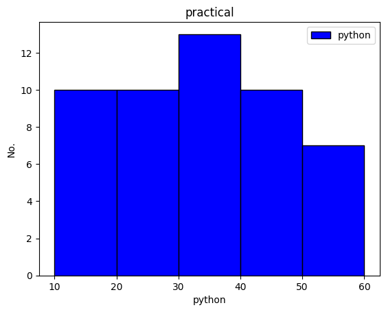

```python
np=[46, 50 ,40 ,12, 26 ,37,59 ,34 ,25, 32, 16 ,50, 21, 16, 31, 24, 18,39 ,40 ,29 ,49 ,19 ,42 ,16,
 46, 59 ,46 ,39 ,39 ,40 ,57 ,20 ,35 ,11 ,52 ,34 ,39, 38 ,16 ,28, 32 ,24 ,26 ,46 ,53 ,17, 37 ,42,
 21, 18]
l=[10,20,30,40,50,60]
plt.hist(np,color="b",bins=l,edgecolor="black",label="python")

plt.title("practical")
plt.xlabel("python")
plt.ylabel("No.")

plt.legend()
plt.show()
```

**axvline is used to markup or divide the hist bar into two parts**

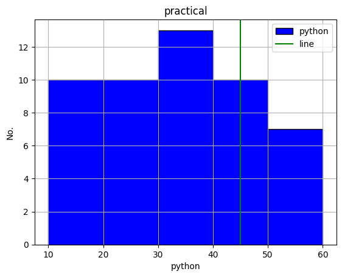

```python
np=[46, 50 ,40 ,12, 26 ,37,59 ,34 ,25, 32, 16 ,50, 21, 16, 31, 24, 18,39 ,40 ,29 ,49 ,19 ,42 ,16,
 46, 59 ,46 ,39 ,39 ,40 ,57 ,20 ,35 ,11 ,52 ,34 ,39, 38 ,16 ,28, 32 ,24 ,26 ,46 ,53 ,17, 37 ,42,
 21, 18]
l=[10,20,30,40,50,60]
plt.hist(np,color="b",bins=l,edgecolor="black",label="python")

plt.title("practical")
plt.xlabel("python")
plt.ylabel("No.")

plt.axvline(45,color="g",label="line")

plt.grid()
plt.legend()
plt.show()
```

# pie chart all concepts

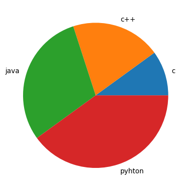

```python
import matplotlib.pyplot as plt

x=[10,20,30,40]
y=["c","c++","java","pyhton"]

plt.pie(x,labels=y)

plt.show()
```

**explode parameter it clears the visual of the pie part by removong from the whole piechart**

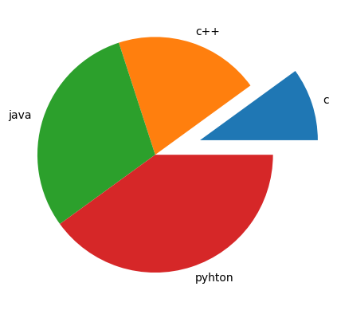

```python
x=[10,20,30,40]
y=["c","c++","java","pyhton"]
ex=[0.4,0.0,0.0,0.0]

plt.pie(x,labels=y,explode=ex)

plt.show()
```

**to show the percentage in the piegraph by using autopct="%0.1f%%"**

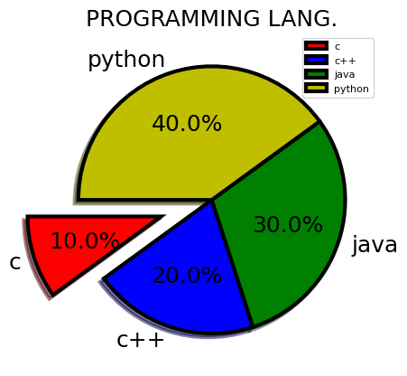

```python
x=[10,20,30,40]
y=["c","c++","java","python"]
ex=[0.4,0.0,0.0,0.0]
c=["r",'b','g','y']

plt.pie(x,labels=y,explode=ex,colors=c,autopct="%0.1f%%",shadow=True,
        radius=1.0,labeldistance=1.1,startangle=180,
        textprops={"fontsize":18},wedgeprops={"linewidth":3,"edgecolor":"black"},
        )
plt.title("PROGRAMMING LANG.",fontsize=18)

plt.legend(loc=1,fontsize=8)
plt.show()
```

**multi pie chart**

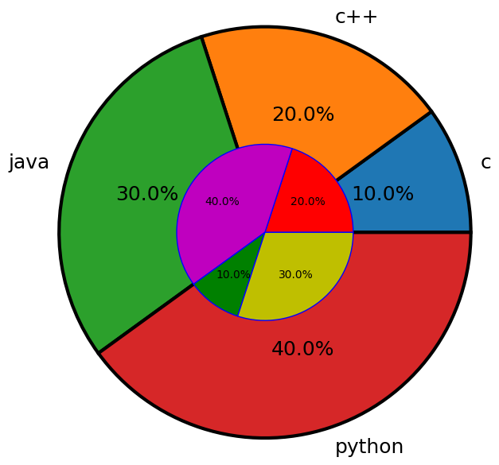

```python
x=[10,20,30,40]
y=["c","c++","java","python"]
x1=[20,40,10,30]

c=["r","m","g",'y']

plt.pie(x,labels=y,radius=1.75,autopct="%0.1f%%",
        textprops={"fontsize":18},
        wedgeprops={"linewidth":3,"edgecolor":"black"})
plt.pie(x1,radius=0.75,colors=c,autopct="%0.1f%%",
        wedgeprops={"linewidth":1,"edgecolor":"blue"})


plt.show()
```

**HOW TO PLOT DONUT PIE GRAPH CHART**

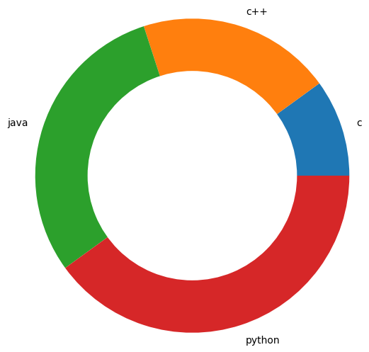

```python
x=[10,20,30,40]
y=["c","c++","java","python"]

c=["r",'b','g','y']

plt.pie(x,labels=y,radius=1.5)
plt.pie([1],colors="w")
plt.show()
```

**another method**

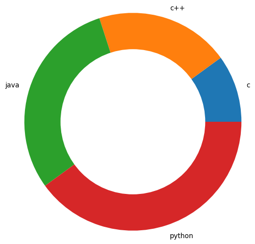

```python
x=[10,20,30,40]
y=["c","c++","java","python"]

c=["r",'b','g','y']

plt.pie(x,labels=y,radius=1.5)
cr=plt.Circle(xy=(0,0),radius=1,facecolor="w")
plt.gca().add_artist(cr)


plt.show()
```

# HOW TO USE STEM PLOT

**"linefmt=" is use to change the stem plot line format**

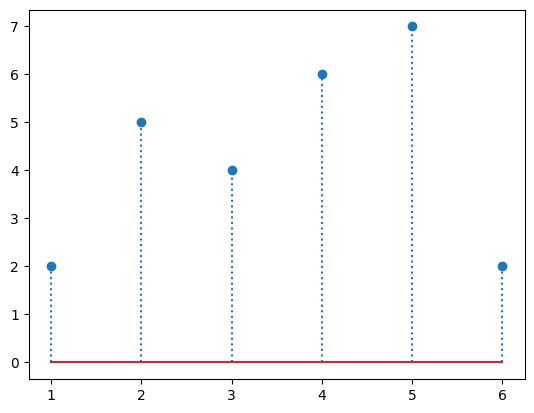

```python
import matplotlib.pyplot as plt

x=[1,2,3,4,5,6]
y=[2,5,4,6,7,2]

plt.stem(x,y,linefmt=":")

plt.show()
```

**markerfmt parameter use to change the shape or color of the dot**

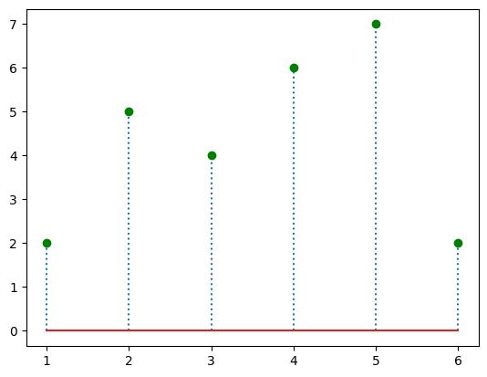

```python
import matplotlib.pyplot as plt

x=[1,2,3,4,5,6]
y=[2,5,4,6,7,2]

plt.stem(x,y,linefmt=":",markerfmt="go")

plt.show()
```

**bottom parameter can be used to read tyhe from required point like below we used to read our data from 2**

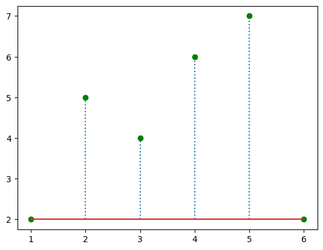

```python
import matplotlib.pyplot as plt

x=[1,2,3,4,5,6]
y=[2,5,4,6,7,2]

plt.stem(x,y,linefmt=":",markerfmt="go",bottom=2)

plt.show()
```

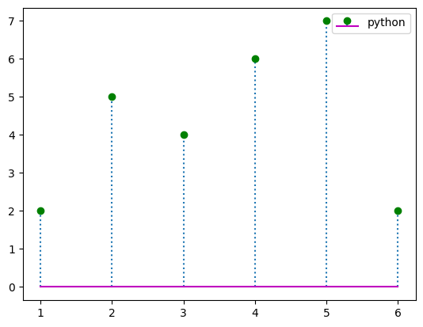

```python
import matplotlib.pyplot as plt

x=[1,2,3,4,5,6]
y=[2,5,4,6,7,2]

plt.stem(x,y,linefmt=":",markerfmt="go",bottom=0,basefmt="m",
         label="python")


plt.legend()
plt.show()
```

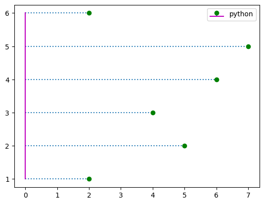

```python
import matplotlib.pyplot as plt

x=[1,2,3,4,5,6]
y=[2,5,4,6,7,2]

plt.stem(x,y,linefmt=":",markerfmt="go",
         bottom=0,basefmt="m",label="python",orientation="horizontal")


plt.legend()
plt.show()
```

# ALL ABOUT BOX PLOT AND WHISKER PLOT

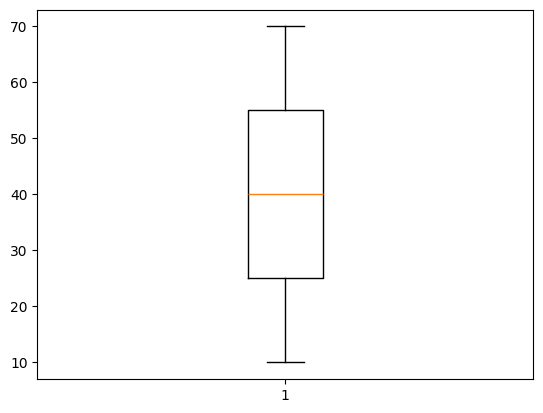

```python
import matplotlib.pyplot as plt

x=[10,20,30,40,50,60,70]


plt.boxplot(x)



plt.show()
```

**notch parameter change the shape of box plot to notch**

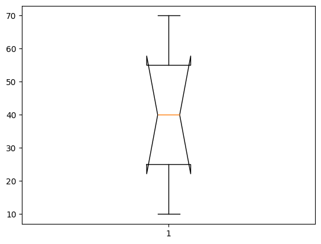

```python
import matplotlib.pyplot as plt

x=[10,20,30,40,50,60,70]


plt.boxplot(x,notch=True)



plt.show()
```

**vert= parameter can change the box plot to vertically and width= parameter can used to increase or decrease the width of box plot**

**adding label we have to give data as a list**

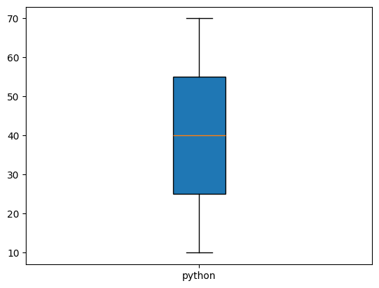

```python
import matplotlib.pyplot as plt

x=[10,20,30,40,50,60,70]


plt.boxplot(x,tick_labels=["python"],patch_artist=True)



plt.show()
```

**showmeans parameter can be used to show means pointer between the line as a triangle**

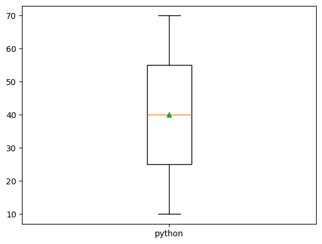

```python
x=[10,20,30,40,50,60,70]


plt.boxplot(x,tick_labels=["python"],showmeans=True)



plt.show()
```

**the outler (a circle above the plot) is shown it means the data is out of range**

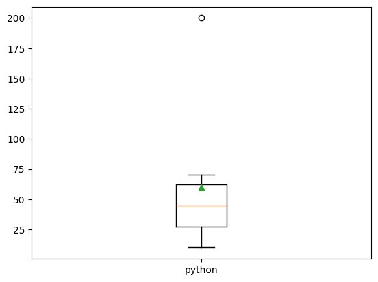

```python
x=[10,20,30,40,50,60,70,200]


plt.boxplot(x,tick_labels=["python"],showmeans=True)



plt.show()
```

**to join whisk to outler we use whis parameter**

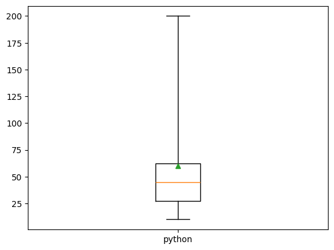

```python
x=[10,20,30,40,50,60,70,200]


plt.boxplot(x,tick_labels=["python"],showmeans=True,whis=4)



plt.show()
```

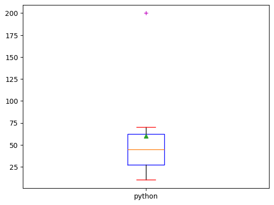

```python
x=[10,20,30,40,50,60,70,200]


plt.boxplot(x,tick_labels=["python"],showmeans=True,
            sym="m+",boxprops=dict(color="blue"),capprops=dict(color="r"),
           )



plt.show()
```

**plot multiple box plot**

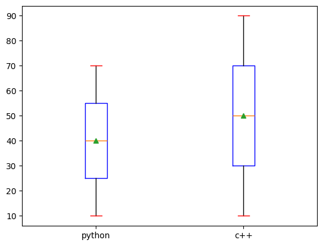

```python
x=[10,20,30,40,50,60,70]
x1=[10,20,40,60,50,80,90]

y=[x,x1]
plt.boxplot(y,tick_labels=["python","c++"],showmeans=True,
            sym="m+",boxprops=dict(color="blue"),capprops=dict(color="r"),
           )



plt.show()
```

# how to plot stack plot or area plot

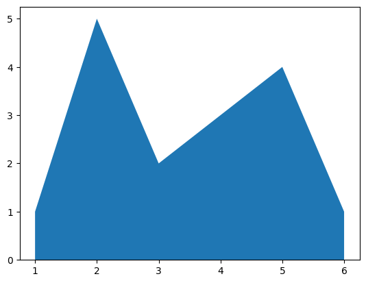

```python
import matplotlib.pyplot as plt

x=[1,2,3,4,5,6]
area=[1,5,2,3,4,1]




plt.stackplot(x,area)



plt.show()
```

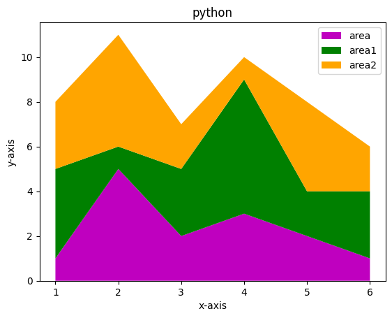

```python
x=[1,2,3,4,5,6]
area=[1,5,2,3,2,1]
area1=[4,1,3,6,2,3]
area2=[3,5,2,1,4,2]

lb=['area','area1','area2']

plt.stackplot(x,area,area1,area2,labels=lb,colors=['m','g','orange'],
              )

plt.title("python")
plt.xlabel("x-axis")
plt.ylabel("y-axis")


plt.legend()
plt.show()
```

# HOW TO CREATE STEP PLOT

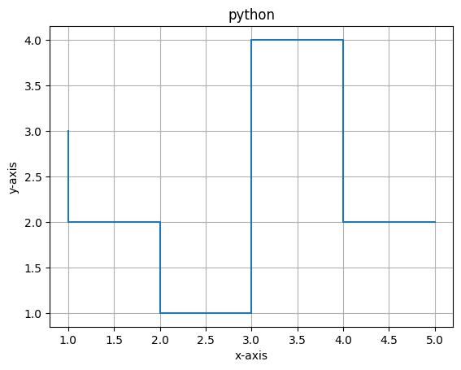

```python
import matplotlib.pyplot as plt

x=[1,2,3,4,5]
y=[3,2,1,4,2]

plt.step(x,y)

plt.title("python")
plt.xlabel("x-axis")
plt.ylabel("y-axis")



plt.grid()
plt.show()
```

**we use markdown function as to mark the point of labeled data given**

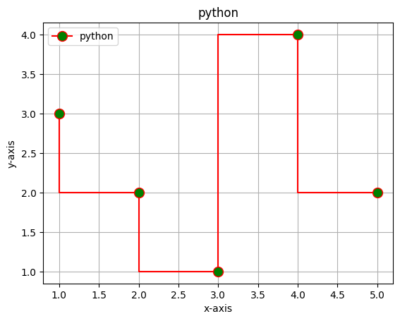

```python
x=[1,2,3,4,5]
y=[3,2,1,4,2]

plt.step(x,y,color="r",marker="o",ms=10,mfc="g",label="python")

plt.title("python")
plt.xlabel("x-axis")
plt.ylabel("y-axis")


plt.legend(loc=2)
plt.grid()
plt.show()
```

# ALL ABOUT FILL_BETWEEN PLOT

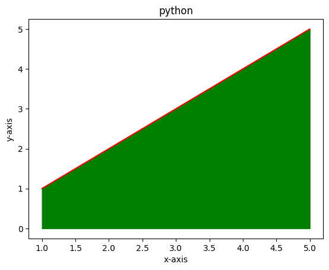

```python
x=[1,2,3,4,5]
y=[1,2,3,4,5]

plt.plot(x,y,color="r")
plt.title("python")
plt.xlabel("x-axis")
plt.ylabel("y-axis")

plt.fill_between(x,y,color="g")



plt.show()
```

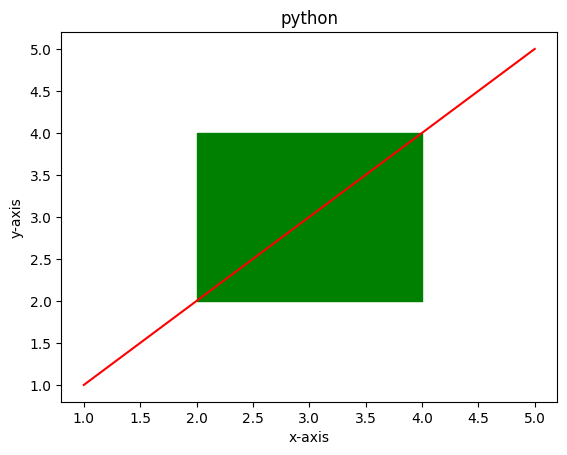

```python
x=[1,2,3,4,5]
y=[1,2,3,4,5]

plt.plot(x,y,color="r")
plt.title("python")
plt.xlabel("x-axis")
plt.ylabel("y-axis")

plt.fill_between(x=[2,4],y1=2,y2=4,color="g")



plt.show()
```

**USE OF WHERE ARGUMENT FOR DESIRED ARE TO BE FILL BETWEEN**

**we use numpy to convert into array and to perform where operations due to comparison works only on numpy arrays**

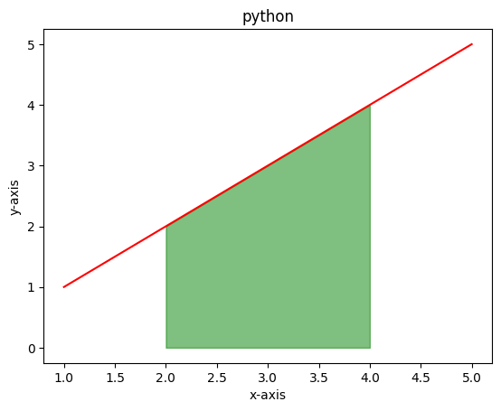

```python
import numpy as np
x=np.array([1,2,3,4,5])
y=np.array([1,2,3,4,5])

plt.plot(x,y,color="r")
plt.title("python")
plt.xlabel("x-axis")
plt.ylabel("y-axis")

plt.fill_between(x,y,color="g",where=(x>=2)&(x<=4),alpha=0.5)



plt.show()
```

# HOW TO PLOT SUBPLOT

**BY USING SUBPLOT PARAMETER WE CAN GET DIFFERENT OR SAME TYPE OF PLOT AT SAME PAGE OR AXIS WHICH DEPENDS ON POSITION OF INDEXING**

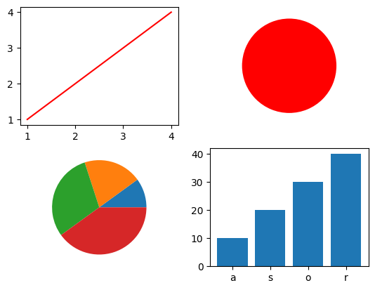

```python
import matplotlib.pyplot as plt

x=[1,2,3,4]
y=[1,2,3,4]
plt.subplot(2,2,1)
plt.plot(x,y,color="r")

plt.subplot(2,2,2)
plt.pie([1],colors="r")

x1=[10,20,30,40]
plt.subplot(2,2,3)
plt.pie(x)


x2=['a','s','o','r']
y2=[10,20,30,40]
plt.subplot(2,2,4)
plt.bar(x2,y2)


plt.show()
```

# HOW TO SAVE EXTERNALLY MATPLOTLIB GRAPH BY COMMAND WHICH WERE CREATED

**we use plt.savefig parameter to save by default as png of plots and for more clearity we use dpi**

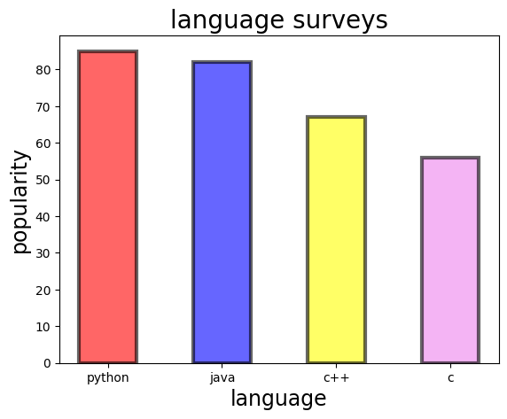

```python
import matplotlib.pyplot as plt

x=["python","java","c++","c"]
y=[85,82,67,56]

plt.xlabel("language",fontsize=17)
plt.ylabel("popularity",fontsize=17)

plt.title("language surveys",fontsize=20)

c=['red','b','yellow',"violet"]

plt.bar(x,y,width=0.5,color=c,align="center",edgecolor="black",linewidth='3',
        linestyle='-',alpha=0.6)


plt.savefig("bargraph.jpg",dpi=2000,facecolor="y",bbox_inches="tight")



plt.show()
```

# HOW TO CHANGE THE AXIS BY USING SOME PARAMETERS

**parameters = xticks(),yticks(),xlim(),ylim(),axis()**

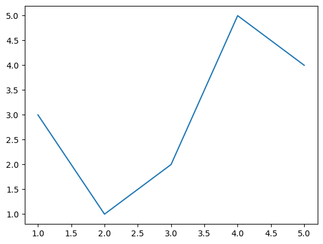

```python
import matplotlib.pyplot as plt
x=[1,2,3,4,5]
y=[3,1,2,5,4]

plt.plot(x,y)

plt.show()
```

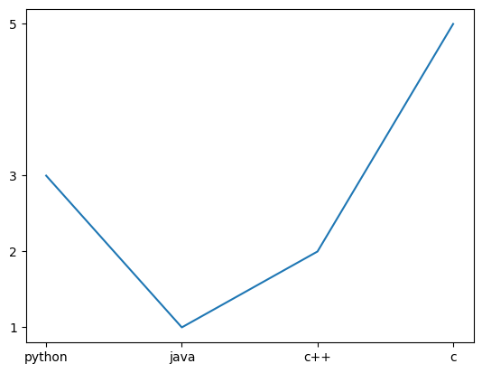

```python
import matplotlib.pyplot as plt
x=[1,2,3,4]
y=[3,1,2,5]

plt.plot(x,y)

plt.xticks(x,labels=["python","java","c++","c"])
plt.yticks(y)


plt.show()
```

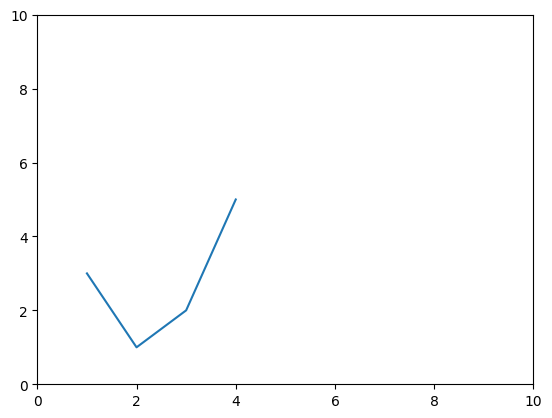

```python
x=[1,2,3,4]
y=[3,1,2,5]

plt.plot(x,y)

plt.xlim(0,10)
plt.ylim(0,10)

plt.show()
```

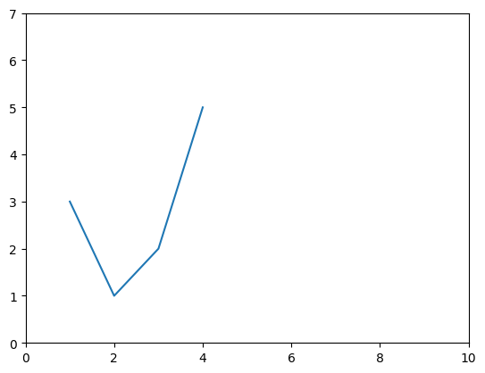

```python
x=[1,2,3,4]
y=[3,1,2,5]

plt.plot(x,y)

plt.axis([0,10,0,7])


plt.show()
```

# working with text while plotting graph

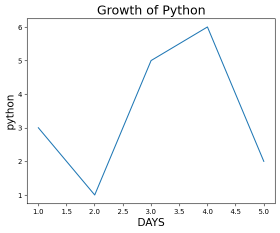

```python
import matplotlib.pyplot as plt

x=[1,2,3,4,5]
y=[3,1,5,6,2]

plt.plot(x,y)

plt.title("Growth of Python",fontsize=18)
plt.xlabel("DAYS",fontsize=15)
plt.ylabel("python",fontsize=15)

plt.show()
```

**for adding a text at a particular point of plot we use plt.text()**

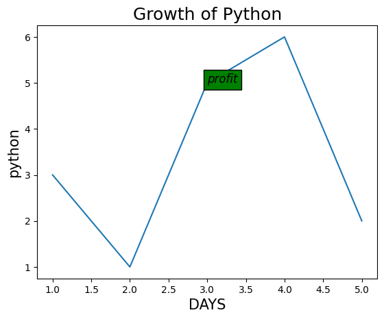

```python
x=[1,2,3,4,5]
y=[3,1,5,6,2]

plt.plot(x,y)

plt.title("Growth of Python",fontsize=18)
plt.xlabel("DAYS",fontsize=15)
plt.ylabel("python",fontsize=15)

plt.text(3,5,"profit",fontsize=12,style="italic",
         bbox={"facecolor":"green"})



plt.show()
```

**we use plt.anotate() parameter to point an arrow with text to any position on axis**

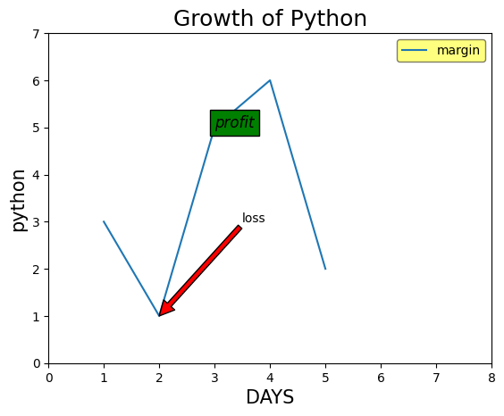

```python
x=[1,2,3,4,5]
y=[3,1,5,6,2]

plt.plot(x,y)

plt.title("Growth of Python",fontsize=18)
plt.xlabel("DAYS",fontsize=15)
plt.ylabel("python",fontsize=15)

plt.text(3,5,"profit",fontsize=12,style="italic",
         bbox={"facecolor":"green"})

plt.annotate("loss",xy=(2,1),xytext=(3.5,3),
             arrowprops=dict(facecolor="red",shrink=100))

plt.axis([0,8,0,7])


plt.legend(["margin"],loc=1,facecolor="yellow",edgecolor="black",framealpha=0.5)
plt.show()
```